# Milestone-shiny-App-All-In-One

Student!

12/04/2020

Executive Summary

As part of Data Science Course Capstone project, this milestone report demonstrates the work done on exploratory data analysis and modeling for text prediction purposes. To get started with the Data Science Capstone Project, the working directory is verified and the data is downloaded from the course location from https://d396qusza40orc.cloudfront.net/dsscapstone/dataset/Coursera-SwiftKey.zip.

This is an attempt to explore the basics and by no means doesn’t represent a complete understanding of the subject matter. A number of method has been tried and used, for example, to read few lines of the data, as part learning and understanding the process. Some approach may have been irrelevant to the current project.

#Set the work directory, to make sure.

```r
getwd()
```

```
## [1] "/Users/Amsalubberi/Desktop/GFinale"
```

#Install needed package, text minig (tm) and other needed packages.

```r
library(tm)
```

```r
library(ngram)
library(stringi)
library(stringr)
library(corpus)
library(lattice)
library(ggplot2)
library(knitr)
library(R.utils)
library(RWeka)
library(dplyr)
library(doParallel)
library(wordcloud)
library(SnowballC)
```

```r
blogs <- readLines("~/Desktop/GFinale/en_US.blogs.txt", encoding = "UTF-8")
```

```r
news <- readLines("~/Desktop/GFinale/en_US.news.txt", encoding = "UTF-8")
```

```r
Twitter <- readLines("~/Desktop/GFinale/en_US.twitter.txt", encoding = "UTF-8", skipNul = TRUE)
```

#The object size for each file is checked to make sure for sample purposes.

```r
object.size(blogs)
```

```
## 267758632 bytes
```

```r
object.size(news)
```

```
## 269840992 bytes
```

```r
object.size(Twitter)
```

```
## 334484992 bytes
```

# Here a different approach is used to read few lines of the head of the data.

```r
data = blogs
print(head(blogs, n = 5))
```

```
## [1] "In the years thereafter, most of the Oil fields and platforms were named after pagan “gods”."
## [2] "We love you Mr. Brown."
## [3] "Chad has been awesome with the kids and holding down the fort while I work later than usual! The kids have been busy together playing Skylander on the XBox together, after Kyan cashed in his $$$ from his piggy bank. He wanted that game so bad and used his gift card from his birthday he has b…
## [4] "so anyways, i am going to share some home decor inspiration that i have been storing in my folder on the puter. i have all these amazing images stored away ready to come to life when we get our home."
## [5] "With graduation season right around the corner, Nancy has whipped up a fun set to help you out with not only your graduation cards and gifts, but any occasion that brings on a change in one's life. I stamped the images in Memento Tuxedo Black and cut them out with circle Nestabilities. I emb…
```

```r
data = news
print(head(news, n = 5))
```

```
## [1] "He wasn't home alone, apparently."
## [2] "The St. Louis plant had to close. It would die of old age. Workers had been making cars there since the onset of mass automotive production in the 1920s."
## [3] "WSU's plans quickly became a hot topic on local online sites. Though most people applauded plans for the new biomedical center, many deplored the potential loss of the building."
## [4] "The Alaimo Group of Mount Holly was up for a contract last fall to evaluate and suggest improvements to Trenton Water Works. But campaign finance records released this week show the two employees donated a total of $4,500 to the political action committee (PAC) Partners for Progress in early…
## [5] "And when it's often difficult to predict a law's impact, legislators should think twice before carrying any bill. Is it absolutely necessary? Is it an issue serious enough to merit their attention? Will it definitely not make the situation worse?"
```

```r
data = Twitter
print(head(Twitter, n = 5))
```

```
## [1] "How are you? Btw thanks for the RT. You gonna be in DC anytime soon? Love to see you. Been way, way too long."
## [2] "When you meet someone special... you'll know. Your heart will beat more rapidly and you'll smile for no reason."
## [3] "they've decided its more fun if I don't."
## [4] "So Tired D; Played Lazer Tag & Ran A LOT D; Ughh Going To Sleep Like In 5 Minutes ;)"
## [5] "Words from a complete stranger! Made my birthday even better :)"
```

#The training and test data for the blogs data

```r
train_in_bl <- sample(1:nrow(data.frame(blogs)), 0.90 * nrow(data.frame(blogs)))
test_in_bl <- setdiff(1:nrow(data.frame(blogs)), train_in_bl)
```

#The training and test data for the news data.

```r
train_in_news <- sample(1:nrow(data.frame(news)), 0.9 * nrow(data.frame(news)))
test_in_news <- setdiff(1:nrow(data.frame(news)), train_in_news)
```

#The training and test data for the twitter data.

```r
train_in_twt <- sample(1:nrow(data.frame(Twitter)), 0.9 * nrow(data.frame(Twitter)))
test_in_twt <- setdiff(1:nrow(data.frame(Twitter)), train_in_twt)
```

```r
mydata <- data
print(head(mydata, n = 10))
```

```
##  [1] "How are you? Btw thanks for the RT. You gonna be in DC anytime soon? Love to see you. Been way, way too long."
##  [2] "When you meet someone special... you'll know. Your heart will beat more rapidly and you'll smile for no reason."
##  [3] "they've decided its more fun if I don't."
##  [4] "So Tired D; Played Lazer Tag & Ran A LOT D; Ughh Going To Sleep Like In 5 Minutes ;)"
##  [5] "Words from a complete stranger! Made my birthday even better :)"
##  [6] "First Cubs game ever! Wrigley field is gorgeous. This is perfect. Go Cubs Go!"
##  [7] "i no! i get another day off from skool due to the wonderful snow (: and THIS wakes me up...damn thing"
##  [8] "I'm coo... Jus at work hella tired r u ever in cali"
##  [9] "The new sundrop commercial ...hehe love at first sight"
## [10] "we need to reconnect THIS WEEK"
```

# Another approach is used here to read head and tail of the data.

```r
dim.data.frame(blogs)
```

```
## [1]      0 899288
```

```r
str(blogs)
```

```
##  chr [1:899288] "In the years thereafter, most of the Oil fields and platforms were named after pagan “gods”." ...
```

```r
head(blogs)
```

```
## [1] "In the years thereafter, most of the Oil fields and platforms were named after pagan “gods”."
## [2] "We love you Mr. Brown."
## [3] "Chad has been awesome with the kids and holding down the fort while I work later than usual! The kids have been busy together playing Skylander on the XBox together, after Kyan cashed in his $$$ from his piggy bank. He wanted that game so bad and used his gift card from his birthday he has b…
## [4] "so anyways, i am going to share some home decor inspiration that i have been storing in my folder on the puter. i have all these amazing images stored away ready to come to life when we get our home."
## [5] "With graduation season right around the corner, Nancy has whipped up a fun set to help you out with not only your graduation cards and gifts, but any occasion that brings on a change in one's life. I stamped the images in Memento Tuxedo Black and cut them out with circle Nestabilities. I emb…
## [6] "If you have an alternative argument, let's hear it! :)"
```

```r
tail(blogs)
```

```
## [1] "He's really making good progress and we have several big piles that will need to be burned come spring. This isn't a true before and after, but here is a shot of what he's starting with and how well he cleans it up (just not the same spot)."
## [2] "The hulking mass of unfinished brick and concrete at 20-13 35th St. is so unsightly, it became a poster child for zoning reform."
## [3] "The 2004 IIFA award ceremony witnessed a contingent of over 450 stars, celebrities, cricketers, industrialists and government leaders over the festive weekend."
## [4] "Plus, I have also been allowing myself not to get ‘stressed’ over things that have not been done! If the ironing is not done right now, it’s not the end of the world! If that phone call is made tomorrow rather than today, then that’s OK too! Living in the moment and allowing myself the time …
## [5] "(5) What's the barrier to entry and why is the business sustainable?"
## [6] "In response to an over-whelming number of comments we sat down and created a list of do (s) and don’t (s) – these recommendations are easy to follow and except for - adding some herbs to your rinse . So let’s get begin…"
```

# The summary of each dataset is presented as follows.

```r
summary(blogs)
```

```
##    Length     Class      Mode
##    899288 character character
```

```r
summary(test_in_bl)
```

```
##    Min. 1st Qu.  Median    Mean 3rd Qu.    Max.
##       3  223147  448155  448421  673540  899287
```

```r
summary(news)
```

```
##    Length     Class      Mode
##   1010242 character character
```

```r
summary(test_in_news)
```

```
##    Min. 1st Qu.  Median    Mean 3rd Qu.    Max.
##      38  251941  503265  504159  757130 1010236
```

```r
summary(Twitter)
```

```
##    Length     Class      Mode
##   2360148 character character
```

```r
summary(test_in_twt)
```

```
##    Min. 1st Qu.  Median    Mean 3rd Qu.    Max.
##      10  590952 1180253 1180663 1773148 2360141
```

# The general statstics is as follows.

```r
stri_stats_general(train_in_bl)
```

```
##       Lines LinesNEmpty       Chars CharsNWhite
##      809359      809359     4756307     4756307
```

```r
stri_stats_general(train_in_news)
```

```
##       Lines LinesNEmpty       Chars CharsNWhite
##      909217      909217     5364695     5364695
```

```r
stri_stats_general(train_in_twt)
```

```
##       Lines LinesNEmpty       Chars CharsNWhite
##     2124133     2124133    13869156    13869156
```

```r
summary(train_in_bl)
```

```
##    Min. 1st Qu.  Median    Mean 3rd Qu.    Max.
##       1  225004  449798  449780  674590  899288
```

```r
summary(train_in_news)
```

```
##    Min. 1st Qu.  Median    Mean 3rd Qu.    Max.
##       1  252629  505318  505228  757727 1010242
```

```r
summary(train_in_twt)
```

```
##    Min. 1st Qu.  Median    Mean 3rd Qu.    Max.
##       1  589928 1180053 1180009 1769803 2360148
```

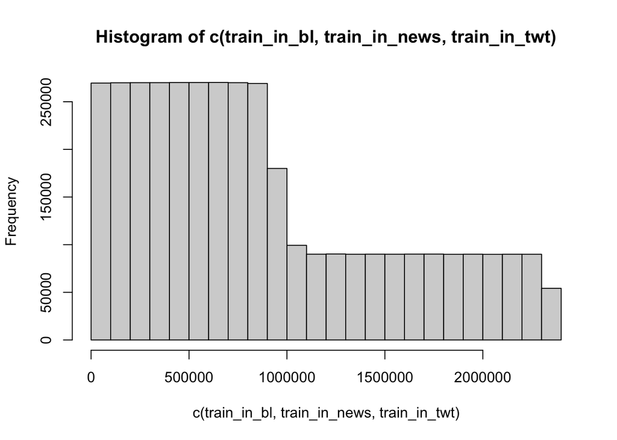

```r
hist(c(train_in_bl, train_in_news, train_in_twt))
```

#The data charachter length is checked to verify them and ready for further analysis.

```r
nchar_blogs <- sum(nchar(blogs))
nchar_news <- sum(nchar(news))
nchar_twt <- sum(nchar(Twitter))
```

#Build N-grams Extract the word and frequency of N-grams.

Cleaning the Data I used several options of the Text Mining (TM) package to clean up the data for the purpose of creating ngrams. Some of the tasks I used to clean up the data were:

Strip Whitespace, Lower Case, Remove Punctuation, Remove Numbers, Plain Text Conversion. First I created the sample data.

```r
sample_data <- c(sample(blogs,length(train_in_bl)*0.1),
               sample(news,length(train_in_news)*0.1),
               sample(Twitter,length(train_in_twt)*0.01))
length(sample_data)
```

```
## [1] 193097
```

```r
p_data <- c(sample(blogs, length(train_in_bl)*0.1),
            sample(news, length(train_in_news)*0.1),
            sample(Twitter, length(train_in_twt)*0.01))
length(p_data)
```

```
## [1] 193097
```

```r
set.seed(123)
corpus <- VCorpus(VectorSource(sample_data))

## Cleaning the dataset
corpus <- tm_map(corpus, stripWhitespace)
corpus <- tm_map(corpus, tolower)
corpus <- tm_map(corpus, removePunctuation)
corpus <- tm_map(corpus, removeNumbers)
corpus <- tm_map(corpus, PlainTextDocument)
corpus <- tm_map(corpus, removeWords, stopwords("english"))
```

```r
file <- readLines("Text_Predictor.R", encoding = "UTF-8")
```

```r
set.seed(999)
sBlog <- blogs[sample(1:length(blogs),20000)]
sNews <- news[sample(1:length(news),20000)]
sTwit <- Twitter[sample(1:length(Twitter),20000)]
sData <- list(sBlog, sNews, sTwit)
```

# Create corpus and clean the data

```r
badwords <- readLines("bad_word.txt", encoding = "latin1", warn=FALSE, skipNul=TRUE)
sD_Corp <- VCorpus(VectorSource(sData))
toSpace <- content_transformer(function(x, pattern) gsub(pattern, " ", x))
sD_Corp <- tm_map(sD_Corp, toSpace, "(f|ht)tp(s?)://(.*)[.][a-z]+")
sD_Corp <- tm_map(sD_Corp, toSpace, "@[^\\s]+")
sD_Corp <- tm_map(sD_Corp, removeWords, c("i","I"))
sD_Corp <- tm_map(sD_Corp, removeWords, badwords)
sD_Corp <- tm_map(sD_Corp, removeWords,  c(stopwords('english')))
sD_Corp <- tm_map(sD_Corp, removePunctuation)
sD_Corp <- tm_map(sD_Corp, tolower)
sD_Corp <- tm_map(sD_Corp, removeNumbers)
sD_Corp <- tm_map(sD_Corp, stripWhitespace)
sD_Corp <- tm_map(sD_Corp, PlainTextDocument)
```

N-gram Tokenization Using the developed corpus, I needed to look at speech patterns and investigate sequenced word pairs, syllables, lettering, etc. via n-gram modeling methodology. Using word frequencies within the n-gram models, unigrams, bigrams and trigrams were creatd.

# N-Grams

```r
uToken <- function(x) {
        NGramTokenizer(x, Weka_control(min = 1, max = 1))
}
Unigram <- DocumentTermMatrix(sD_Corp, control = list(tokenize = uToken))

bToken <- function(x) {
        NGramTokenizer(x, Weka_control(min = 2, max = 2))
}
Bigram <- DocumentTermMatrix(sD_Corp, control = list(tokenize = bToken))

tToken <- function(x) {
        NGramTokenizer(x, Weka_control(min = 3, max = 3))
}
Trigram <- DocumentTermMatrix(sD_Corp, control = list(tokenize = tToken))
```

Exploratory Analysis After completing N-gram modeling for unigrams, bigrams and trigrams, the total frequencies are determined and plotted below

Unigram Frequency (Top 10) #Unigram

```r
ufreq <- sort(colSums(as.matrix(Unigram)),decreasing = TRUE)
ufreq_df <- data.frame(word = names(ufreq), frequency = ufreq)
head(ufreq_df, 10)
```

```
##      word frequency
## the   the      9821
## said said      5846
## will will      5487
## one   one      5211
## just just      4507
## can   can      4094
## like like      4062
## time time      3603
## get   get      3495
## new   new      3212
```

Unigram Plot #Unigram

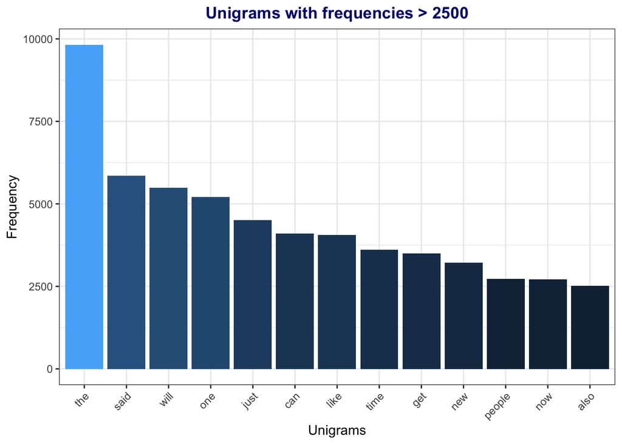

```r
ufreq_df %>%
        filter(frequency > 2500) %>%
        ggplot(aes(reorder(word,-frequency), frequency, fill=frequency)) +
        geom_bar(stat = "identity") +
        ggtitle("Unigrams with frequencies > 2500") +
        xlab("Unigrams") + ylab("Frequency") +
        theme_bw() +
        theme(plot.title = element_text(color="navyblue", face="bold",hjust=0.5)) +
        theme(axis.text.x = element_text(angle = 45, hjust = 1)) +
        theme(legend.position="none")
```

Bigram Frequency (Top 10)

```r
bfreq <- sort(colSums(as.matrix(Bigram)),decreasing = TRUE)
bfreq_df <- data.frame(word = names(bfreq), frequency = bfreq)
head(bfreq_df, 10)
```

```
##                    word frequency
## last year     last year       350
## new york       new york       338
## right now     right now       326
## years ago     years ago       270
## high school high school       269
## last week     last week       220
## first time   first time       217
## st louis       st louis       202
## last night   last night       191
## new jersey   new jersey       190
```

Bigram Plot

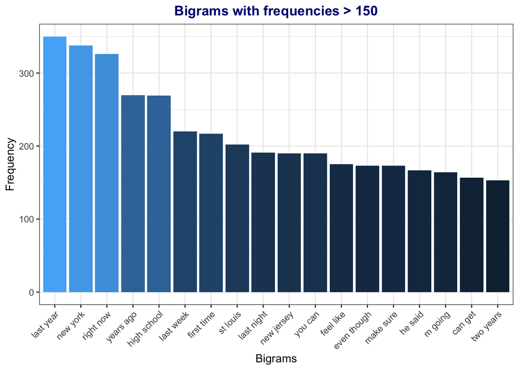

```r
bfreq_df %>%
        filter(frequency > 150) %>%
        ggplot(aes(reorder(word,-frequency), frequency, fill=frequency)) +
        geom_bar(stat = "identity") +
        ggtitle("Bigrams with frequencies > 150") +
        xlab("Bigrams") + ylab("Frequency") +
        theme_bw() +
        theme(plot.title = element_text(color="navyblue", face="bold",hjust=0.5)) +
        theme(axis.text.x = element_text(angle = 45, hjust = 1)) +
        theme(legend.position="none")
```

Trigram Frequency (Top 10)

```r
tfreq <- sort(colSums(as.matrix(Trigram)),decreasing = TRUE)
tfreq_df <- data.frame(word = names(tfreq), frequency = tfreq)
head(tfreq_df, 10)
```

```
##                                                    word frequency
## new york city                             new york city        47
## president barack obama           president barack obama        33
## happy mothers day                     happy mothers day        32
## happy new year                           happy new year        32
## none repeat scroll                   none repeat scroll        30
## repeat scroll yellow               repeat scroll yellow        30
## stylebackground none repeat stylebackground none repeat        30
## two years ago                             two years ago        30
## new york times                           new york times        26
## st louis county                         st louis county        24
```

Trigram Plot

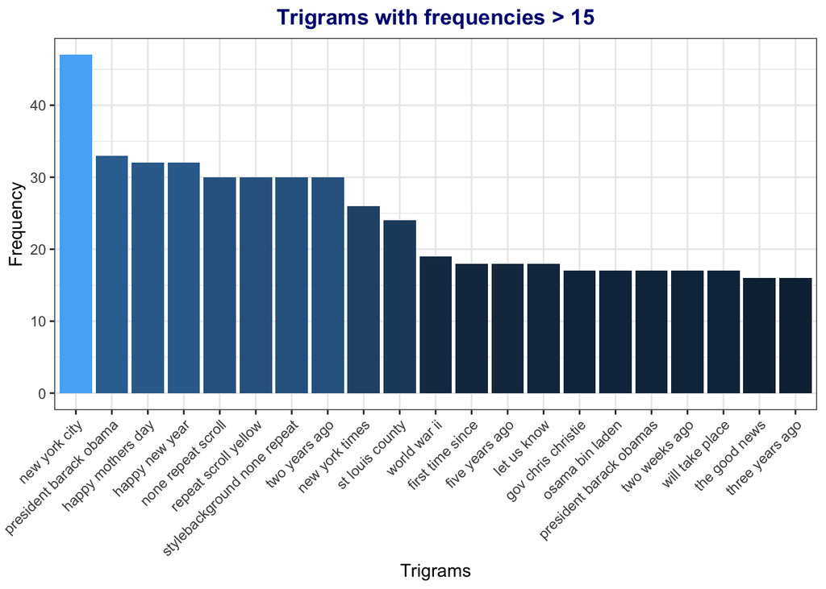

```r
tfreq_df %>%
        filter(frequency > 15) %>%
        ggplot(aes(reorder(word,-frequency), frequency, fill=frequency)) +
        geom_bar(stat = "identity") +
        ggtitle("Trigrams with frequencies > 15") +
        xlab("Trigrams") + ylab("Frequency") +
        theme_bw() +
        theme(plot.title = element_text(color="navyblue", face="bold",hjust=0.5)) +
        theme(axis.text.x = element_text(angle = 45, hjust = 1)) +
        theme(legend.position="none")
```

Although further analysis and development is possible with further study and I have decided to finalize at this stage. Prediction strategies for Shiny app is an easily interactive and inviting interface allowing the user to enter some text allowing the user to enter some text then the prediction algorithm will suggest the next word.